# Task 3

```r
library(tidyverse)
library(maps)

seabird_data <- read_csv("data/clean_data/birds_and_ship_data.csv")
```

## Cleaning process

The data for this analysis comes from two sheets in an excel file relating to seabird sightings and the ships they were sighted from.

# Seabird Sightings Data Analysis

The data have been cleaned, tidied and joined into one clean dataset. This hass been loaded in along with the tidyverse.

### Most individual sightings

Which bird had the most individual sightings?

This question can be answered first by filtering where count is equal to 1 since the question is concerned with individual sightings, not clusters of more than 1. After grouping by species, the sum of all the sightings of each species can be calculated, put in descending order and then cut after the first row.

```r
seabird_data %>%
  # don't need lat/long cols
  select(-lat, -long) %>%
  filter(count == 1) %>%
  group_by(species, species_scientific, species_abbreviation) %>%
  summarise(individual_sightings = sum(count, na.rm = TRUE), .groups = 'drop_last') %>%
  arrange(desc(individual_sightings)) %>%
  head(1)
```

| species | species_scientific | species_abbreviation | individual_sightings |
| --- | --- | --- | --- |
| Wandering albatross sensu lato | Diomedea antipodensis / exulans | DIOANTEXU | 6508 |

### The most seen

Which bird has the highest total sightings?

After grouping by species, the total count can be calculated in the same way as above.

```r
seabird_data %>%
  select(-lat, -long) %>%
  group_by(species, species_scientific, species_abbreviation) %>%
  summarise(sightings = sum(count, na.rm = TRUE), .groups = 'drop_last') %>%
  arrange(desc(sightings)) %>%
  head(1)
```

| species | species_scientific | species_abbreviation | sightings |
| --- | --- | --- | --- |
| Short-tailed shearwater | Puffinus tenuirostris | PUFTEN | 982553 |

### Most seen above -30 lat

To find the seabird with the most sightings above -30 lattitude, the process is above but with a filtration for lat greater than -30.

```r
seabird_data %>%
  select(-long) %>%
  filter(lat > -30) %>%
  group_by(species, species_scientific, species_abbreviation) %>%
  summarise(sightings = sum(count, na.rm = TRUE), .groups = 'drop_last') %>%
  arrange(desc(sightings)) %>%
  head(1)
```

| species | species_scientific | species_abbreviation | sightings |
| --- | --- | --- | --- |
| Wedge-tailed shearwater | Puffinus pacificus | PUFPAC | 855 |

### Number of lone-seabirds

How many different types of birds were only ever seen in groups of 1?

The average no in a sighting for each species can be calculated. After filtering this new column to where the average no in a sighting is one, the number of rows can be counted.

```r
seabird_data %>%
  select(-lat, -long) %>%
  group_by(species, species_scientific, species_abbreviation) %>%
  summarise(avg_sightings = mean(count, na.rm = TRUE), .groups = 'drop_last') %>%
  filter(avg_sightings == 1) %>%
  nrow()
```

```
## [1] 23
```

It might be useful to see which birds they were:

```r
seabird_data %>%
  select(-lat, -long) %>%
  group_by(species, species_scientific, species_abbreviation) %>%
  summarise(avg_sightings = mean(count, na.rm = TRUE), .groups = 'drop_last') %>%
  filter(avg_sightings == 1) %>%
  select(-avg_sightings)
```

| species | species_scientific | species_abbreviation |
| --- | --- | --- |
| Atlantic yellow-nosed mollymawk | Thalassarche chlororhynchos | THACHL |
| Audubon's shearwater | Puffinus lherminieri | PUFLHE |
| Barau's petrel | Pterodroma baraui | PTEBAR |
| Black / Westland petrel | Procellaria parkinsoni / westlandica | PROPARWES |
| Black-faced cormorant | Phalacrocorax fuscescens | PHAFUS |
| Bulwer's petrel | Bulweria bulwerii | BULBUL |
| Caspian tern | Hydroprogne caspia | HYDCAS |
| Crested penguin (unidentified) | Eudyptes / Magadyptes sp | EUDMEG |
| Flesh-footed / Wedge-tailed shearwater | Puffinus carneipes / pacificus | PUFCARPAC |
| Frigatebird (unidentified) | Fregata sp | FRESP |

[output cut: 13 more lines]

### Penguins

After converting the species column to lower case, the rows containing penguins can be found.

```r
penguin_pattern <- "penguin"

penguins <- seabird_data %>%
  mutate(species = str_to_lower(species)) %>%
  filter(str_detect(species, penguin_pattern))
```

```r
penguin_sightings <- penguins %>%
  summarise(sightings = sum(count, na.rm = TRUE), .groups = 'drop_last') %>%
  arrange(desc(sightings))
```

Plotting the penguins

First load in the shape of the world map polygon from the maps package.

```r
earth_map <- map_data("world")
```

Then plot the polygon and the plot each sighting by its lat/long co-ordinate.

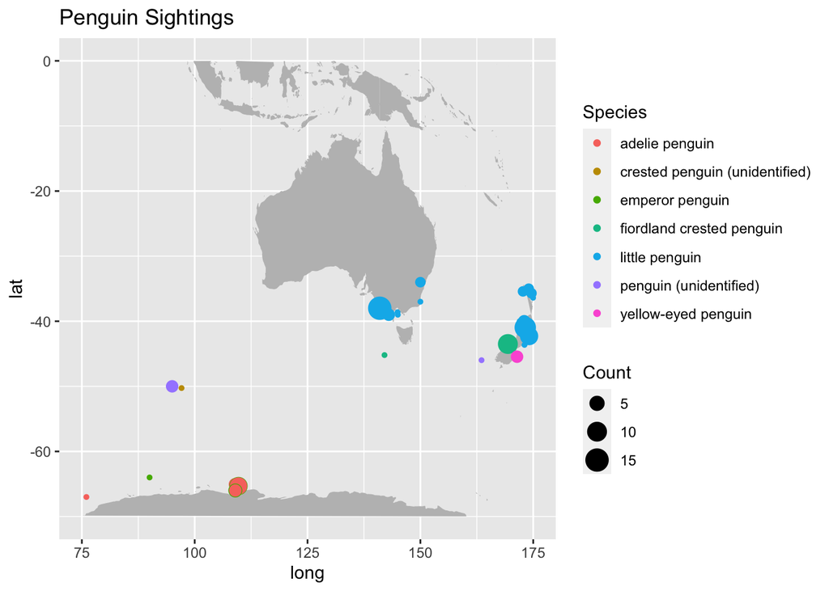

```r
ggplot() +
  geom_polygon(data = earth_map, aes(x = long, y = lat, group = group),
               fill = "grey", alpha = 1.5) +
  geom_point(data = penguins ,
             aes(x = long, y = lat, colour = species, size = count)) +
  labs(color = "Species",
       size = "Count",
       title = "Penguin Sightings") +
  xlim(75, 175) +
  ylim(-70, 0)
```